# Reproducible Research: Homework 1

Claire Wolfe

February 9, 2017

## Introduction

Description from the Course Assignment:

“This assignment makes use of data from a personal activity monitoring device. This device collects data at 5 minute intervals through out the day. The data consists of two months of data from an anonymous individual collected during the months of October and November, 2012 and include the number of steps taken in 5 minute intervals each day.”

The data can be downloaded at https://d396qusza40orc.cloudfront.net/repdata%2Fdata%2Factivity.zip.

## PART 1: Loading and preprocessing the data

Loading the CSV file creates the following dataframe:

```r
activity <- read.csv("activity.csv")
str(activity)
```

```
## 'data.frame':    17568 obs. of  3 variables:
##  $ steps   : int  NA NA NA NA NA NA NA NA NA NA ...
##  $ date    : Factor w/ 61 levels "2012-10-01","2012-10-02",..: 1 1 1 1 1 1 1 1 1 1 ...
##  $ interval: int  0 5 10 15 20 25 30 35 40 45 ...
```

- steps: number of steps taken in a 5 minute interval
- date: date the measurement was taken in YYYY-MM-DD format
- interval: number representing each interval

NOTE: I did not find it necessary to preprocess any of the data. I left the interval values as integers, allowing 0 to represent 00:00, 315 to represent 03:15, 1350 to represent 13:50, etc. All plots will use the integer value to label intervals.

## PART 2: What is mean total number of steps taken per day?

### 1. Calculate the total number of steps taken per day.

```r
total_steps <- aggregate(steps ~ date, data = activity, sum)
print(total_steps)
```

```
##          date steps
## 1  2012-10-02   126
## 2  2012-10-03 11352
## 3  2012-10-04 12116
## 4  2012-10-05 13294
## 5  2012-10-06 15420
## 6  2012-10-07 11015
## 7  2012-10-09 12811
## 8  2012-10-10  9900
## 9  2012-10-11 10304
## 10 2012-10-12 17382
## 11 2012-10-13 12426
## 12 2012-10-14 15098
## 13 2012-10-15 10139
## 14 2012-10-16 15084
```

[output cut: 39 more lines]

### 2. Make a histogram of the total number of steps taken each day.

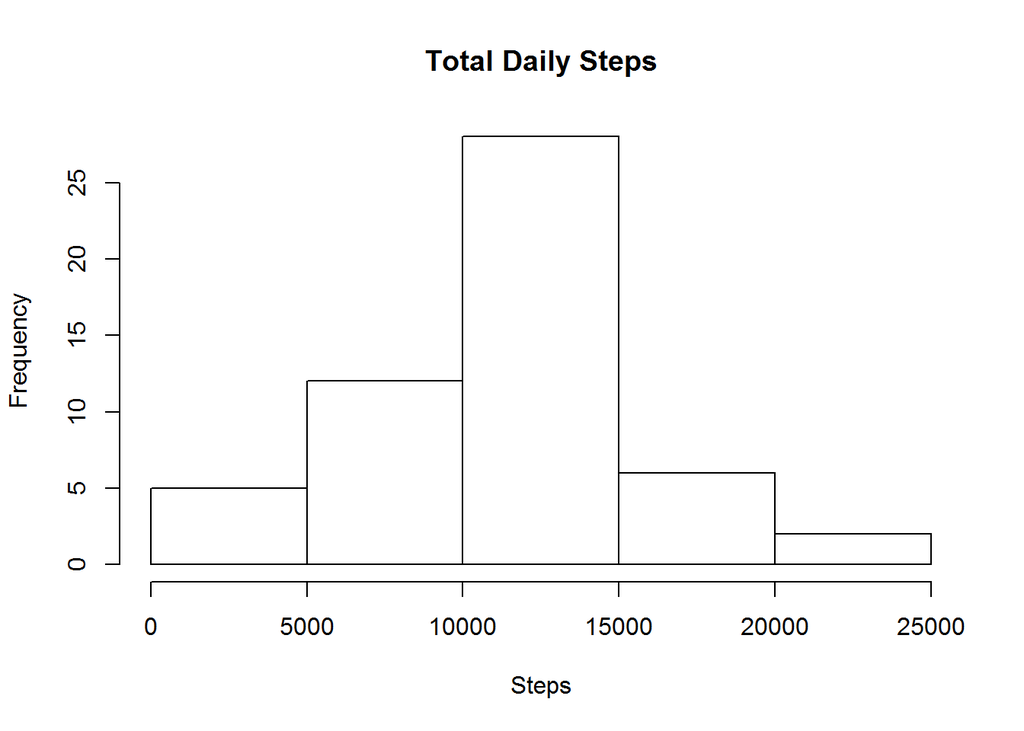

```r
hist(total_steps$steps, main="Total Daily Steps", xlab="Steps")
```

### 3. Calculate and report the mean and median of the total number of steps taken per day.

```r
cat("Mean Daily Steps: ", mean(total_steps$steps, na.rm = TRUE), "\n",
    "Median Daily Steps: ", median(total_steps$steps, na.rm = TRUE), "\n",
    sep = "")
```

```
## Mean Daily Steps: 10766.19
## Median Daily Steps: 10765
```

## PART 3: What is the average daily activity pattern?

### 1. Make a time series plot of the 5-minute interval (x-axis) and the average number of steps taken, averaged across all days (y-axis)

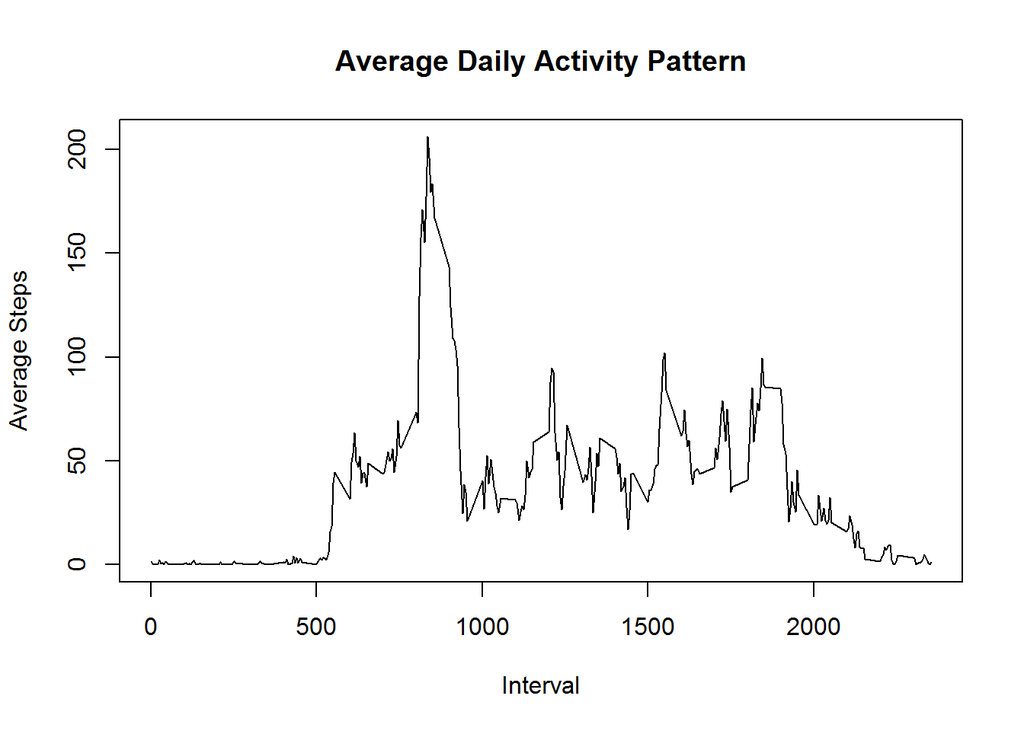

```r
avg_daily_activity <- aggregate(steps ~ interval, data = activity, mean)
plot(avg_daily_activity$interval, avg_daily_activity$steps, type ="l",
     main = "Average Daily Activity Pattern",
     xlab = "Interval", ylab = "Average Steps")
```

### 2. Which 5-minute interval, on average across all the days in the dataset, contains the maximum number of steps?

```r
max_steps <- max(avg_daily_activity$steps)
row <- which (avg_daily_activity$steps == max_steps)
cat("Interval ", avg_daily_activity[row, "interval"],
    " contains the maximum average steps ", max_steps, "\n", sep = "")
```

```
## Interval 835 contains the maximum average steps 206.1698
```

## PART 4: Inputting missing values (The presence of missing days may introduce bias into some calculations or summaries of the data.)

### 1. Calculate and report the total number of missing values in the dataset (i.e. the total number of rows with NAs)

```r
cat("Total Missing Step Values: ", sum(is.na(activity$steps)), "\n", sep = "" )
```

```
## Total Missing Step Values: 2304
```

### 2. Devise a strategy for filling in all of the missing values in the dataset.

I will fill in each missing step value with the average value of that interval over all days. So, for example, any missing step values for interval 835 for any day will be filled with the average steps for that interval, 206 (rounded integer value of 206.1698).

### 3. Create a new dataset that is equal to the original dataset but with the missing data filled in.

```r
## New data set
filled_activity <- activity

## Get list of rows with missing steps
missing_steps <- which(is.na(activity$steps))

## Create a function that will fill in the missing value with the average
## maximum value for that interval.
replace.with.avg <- function (x) {
        ## Get the interval for the missing value.
        interval <- activity[x, "interval"]

        ## Find the average total steps for that interval.
        idx <- which(interval == avg_daily_activity$interval)
        as.integer(avg_daily_activity[idx, "steps"])
}

## Apply replace.with.avg function over all missing rows with missing step
##values.
filled_activity[missing_steps, "steps"] <- sapply(missing_steps,
                                                  replace.with.avg)
str(filled_activity)
```

```
## 'data.frame':    17568 obs. of  3 variables:
##  $ steps   : int  1 0 0 0 0 2 0 0 0 1 ...
##  $ date    : Factor w/ 61 levels "2012-10-01","2012-10-02",..: 1 1 1 1 1 1 1 1 1 1 ...
##  $ interval: int  0 5 10 15 20 25 30 35 40 45 ...
```

### 4a. Make a histogram of the total number of steps taken each day.

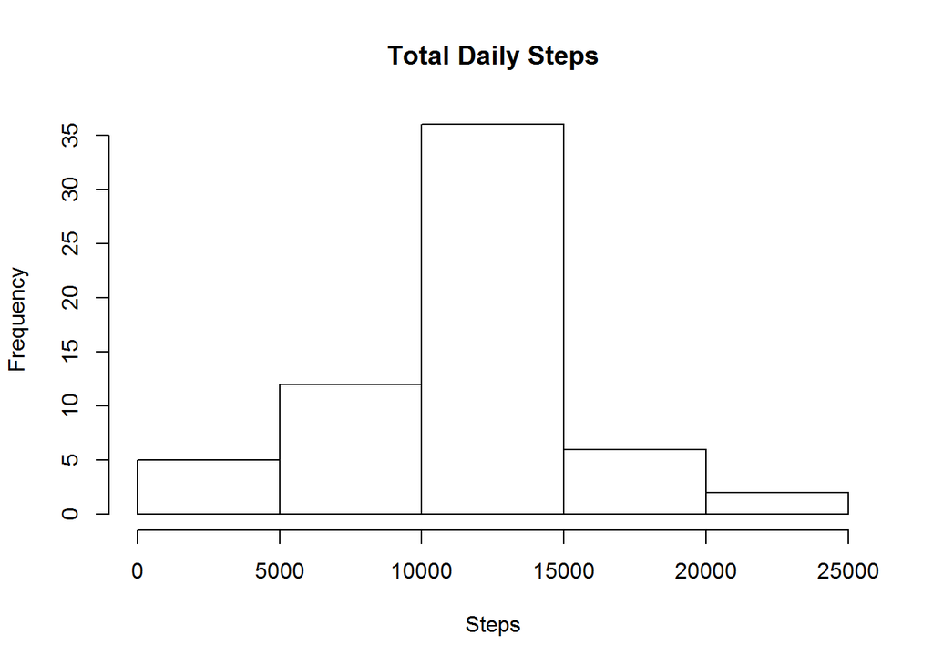

```r
total_filled_steps <- aggregate(steps ~ date, data = filled_activity, sum)
hist(total_filled_steps$steps, main="Total Daily Steps", xlab="Steps")
```

### 4b. Calculate and report the mean and median total number of steps taken per day.

```r
cat("Mean Daily Steps: ", mean(total_filled_steps$steps), "\n",
    "Median Daily Steps: ", median(total_filled_steps$steps), "\n",
    sep = "")
```

```
## Mean Daily Steps: 10749.77
## Median Daily Steps: 10641
```

## PART 5: Are there differences in activity patterns between weekdays and weekends? (Use the dataset with the filled-in missing values for this part.)

## 1. Create a new factor variable in the dataset with two levels - “weekday”and “weekend” indicating whether a given date is a weekday or weekend day.

```r
## Create a vector of each date's weekday name.
weekdays <- weekdays(as.Date(filled_activity$date))

## Set the values to TRUE for weekend dates and FALSE for weekday dates.
weekdays <- weekdays %in% c("Saturday", "Sunday")

## Factor these values to be labeled "weekday" or "weekend".  Add the vector
## as a new column to the filled_activity dataframe.
filled_activity$weekdays <- factor(weekdays, c(FALSE, TRUE),
                                   c("weekday", "weekend"))
str(filled_activity)
```

```
## 'data.frame':    17568 obs. of  4 variables:
##  $ steps   : int  1 0 0 0 0 2 0 0 0 1 ...
##  $ date    : Factor w/ 61 levels "2012-10-01","2012-10-02",..: 1 1 1 1 1 1 1 1 1 1 ...
##  $ interval: int  0 5 10 15 20 25 30 35 40 45 ...
##  $ weekdays: Factor w/ 2 levels "weekday","weekend": 1 1 1 1 1 1 1 1 1 1 ...
```

## 2. Make a panel plot containing a time series plot (i.e. type = “l”) of the 5-minute interval (x-axis) and the average number of steps taken, averaged across all weekday days or weekend days (y-axis).

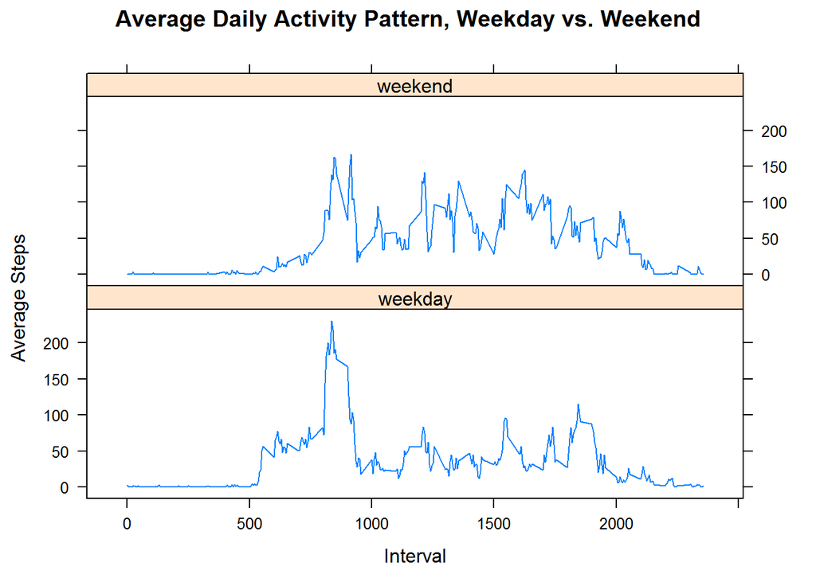

```r
library(lattice)

## Calculate the average number of steps for each interval/weekday
avg_steps_by_weekday <- aggregate(steps ~ interval + weekdays,
                                  data = filled_activity, FUN = "mean")

## Plot the average steps by interval for weekend and weekday.
xyplot(steps ~ interval | weekdays,
            data = avg_steps_by_weekday, type = "l", layout = c(1, 2),
            main = "Average Daily Activity Pattern, Weekday vs. Weekend",
            xlab = "Interval", ylab = "Average Steps")
```